# Effect of Sequencing Center and Population on Total DUF1220

# Questions:

- Should I be treating sequencing centers and populations as random rather than fixed? Are my models correct/do they make sense?

# Setup Code

```r
library(tidyverse)
library(car)
library(reshape2)
library(ggbeeswarm)
rd1000 <- read_delim("~/LabProjects/ReadDepth/data/1000Genomes/1000Genomes_with_unique_regions.txt", "\t")
colnames(rd1000) <- tolower(colnames(rd1000))
# Read in metadata file (sequence.index) to get info like population, sequencing center
metadata <- read_delim("~/LabProjects/ReadDepth/data/1000Genomes/sequence.index",delim = "\t", progress = FALSE)
```

[output not shown]

```r
colnames(metadata)[10] <- "sample"
# Merge the metatdata with the read depth data
# Filter data and select the columns we want to merge
metadata.tomerge <- metadata %>%
  filter(ANALYSIS_GROUP != "exome", INSTRUMENT_MODEL == "Illumina HiSeq 2000", LIBRARY_LAYOUT == "PAIRED") %>% filter(CENTER_NAME != "BCM") %>%
  group_by(sample, CENTER_NAME, POPULATION) %>%
  summarise(tot.reads = sum(READ_COUNT), mean.insert = mean(INSERT_SIZE))
```

```
integer overflow - use sum(as.numeric(.))integer overflow - use sum(as.numeric(.))integer overflow - use sum(as.numeric(.))
```

```r
colnames(metadata.tomerge) <- tolower(colnames(metadata.tomerge))
pop.groups <- read.delim("~/LabProjects/ReadDepth/data/1000Genomes/PopulationGroups.csv", sep = ",")
colnames(pop.groups) <- tolower(colnames(pop.groups))
# Merge metadata and population group information with read depth data
rd1000.data <- inner_join(rd1000, metadata.tomerge)
rd1000.data <- inner_join(rd1000.data, pop.groups)
```

```
joining character vector and factor, coercing into character vector
```

```r
## Summarise data by gene-specific clade groups
# Melt the data frame
rd1000.melt <- melt(rd1000.data, id.vars = c("sample", "center_name", "population", "pop.group", "mean.insert", "tot.reads"))
colnames(rd1000.melt)[7] <- "region"
colnames(rd1000.melt)[8] <- "rd"
# Write it to a file
write.table(rd1000.melt, file = "~/LabProjects/ReadDepth/variation_analysis/1000Genomes-rd-data-melted.txt", sep = "\t",
            row.names=FALSE,
            quote = FALSE)
```

```bash
# Executes the python code that adds information about gene-specific clade groups
python ~/LabProjects/ReadDepth/variation_analysis/for-making-gene-specific-clade-groups/scripts/make-gene-level-clade-groups3.py ~/LabProjects/ReadDepth/variation_analysis/1000Genomes-rd-data-melted.txt ~/LabProjects/ReadDepth/variation_analysis/for-making-gene-specific-clade-groups/supporting-files/clusters-collapse-hls.csv ~/LabProjects/G4/num-108bpHLS-per-gene.txt ~/LabProjects/ReadDepth/variation_analysis/
```

```r
# Read in the data with the gene specific clade group information added
rd1000.groups <- read_delim("~/LabProjects/ReadDepth/variation_analysis/1000Genomes-rd-data-with-groupings.txt", delim = "\t", col_names = FALSE)
colnames(rd1000.groups) <- c("sample","pop", "pop.group","center","mean.insert","tot.reads", "region", "gene.clade","value", "gene_copy", "group", "sample.group")
group.sums.by.sample <- rd1000.groups %>% filter(center != "BCM") %>%
  group_by(sample, pop, pop.group, center, mean.insert,tot.reads,group) %>%
  summarise(group.total = sum(value))
total.duf.by.sample <- group.sums.by.sample %>% group_by(sample) %>%
  summarise(total.duf = sum(group.total))
group.sums.by.sample <- merge(group.sums.by.sample, total.duf.by.sample)
center.test <- group.sums.by.sample %>% mutate(BGI = ifelse(center == "BGI",1,0),
                                               SC = ifelse(center == "SC",1,0),
                                               BI = ifelse(center == "BI",1,0),
                                               ILLUMINA = ifelse(center == "ILLUMINA",1,0),
                                               MPIMG = ifelse(center == "MPIMG",1,0),
                                               WUGSC = ifelse(center == "WUGSC",1,0))
center.test <- center.test %>% mutate(ASW = ifelse(pop == "ASW",1,0),
                                      CEU = ifelse(pop == "CEU",1,0),
                                      CHB = ifelse(pop == "CHB",1,0),
                                      CHS = ifelse(pop == "CHS",1,0),
                                      CLM = ifelse(pop == "CLM",1,0),
                                      FIN = ifelse(pop == "FIN",1,0),
                                      GBR = ifelse(pop == "GBR",1,0),
                                      IBS = ifelse(pop == "IBS",1,0),
                                      JPT = ifelse(pop == "JPT",1,0),
                                      LWK = ifelse(pop == "LWK",1,0),
                                      MXL = ifelse(pop == "MXL",1,0),
                                      PUR = ifelse(pop == "PUR",1,0),
                                      TSI = ifelse(pop == "TSI",1,0),
                                      YRI = ifelse(pop == "YRI",1,0))
center.test <- center.test %>% select(-group, -group.total)
center.test <- center.test %>% group_by(sample, pop, pop.group, center, mean.insert, tot.reads, BGI, SC, BI, ILLUMINA, MPIMG, WUGSC, ASW, CEU, CHB, CHS, CLM, FIN, GBR, IBS, JPT, LWK, MXL, PUR, TSI, YRI) %>% summarise(total.duf = median(total.duf))
```

Show the head of the data frame used for the below analysis

```r
head(center.test)
```

| sample | pop | pop.group | center | mean.insert | tot.reads | BGI | SC | BI | ILLUMINA | MPIMG | WUGSC | ASW | CEU | CHB | CHS | CLM | FIN | GBR | IBS | JPT | LWK | MXL | PUR | TSI | YRI | total.duf |
| --- | --- | --- | --- | --- | --- | --- | --- | --- | --- | --- | --- | --- | --- | --- | --- | --- | --- | --- | --- | --- | --- | --- | --- | --- | --- | --- |
| HG00148 | GBR | European | SC | 348.0000 | 172875619 | 0 | 1 | 0 | 0 | 0 | 0 | 0 | 0 | 0 | 0 | 0 | 0 | 1 | 0 | 0 | 0 | 0 | 0 | 0 | 0 | 859.4396 |
| HG00149 | GBR | European | SC | 349.6667 | 133457781 | 0 | 1 | 0 | 0 | 0 | 0 | 0 | 0 | 0 | 0 | 0 | 0 | 1 | 0 | 0 | 0 | 0 | 0 | 0 | 0 | 714.6434 |
| HG00160 | GBR | European | BI | 500.0000 | 246207777 | 0 | 0 | 1 | 0 | 0 | 0 | 0 | 0 | 0 | 0 | 0 | 0 | 1 | 0 | 0 | 0 | 0 | 0 | 0 | 0 | 897.5084 |
| HG00185 | FIN | European | SC | 349.6667 | 128821526 | 0 | 1 | 0 | 0 | 0 | 0 | 0 | 0 | 0 | 0 | 0 | 1 | 0 | 0 | 0 | 0 | 0 | 0 | 0 | 0 | 901.0357 |
| HG00232 | GBR | European | BGI | 472.0000 | 92112458 | 1 | 0 | 0 | 0 | 0 | 0 | 0 | 0 | 0 | 0 | 0 | 0 | 1 | 0 | 0 | 0 | 0 | 0 | 0 | 0 | 867.9092 |
| HG00236 | GBR | European | BGI | 462.5000 | 310699071 | 1 | 0 | 0 | 0 | 0 | 0 | 0 | 0 | 0 | 0 | 0 | 0 | 1 | 0 | 0 | 0 | 0 | 0 | 0 | 0 | 1014.8969 |

### Generate summary stats on number of samples from each population and sequencing center

#### Number of samples sequenced at each center

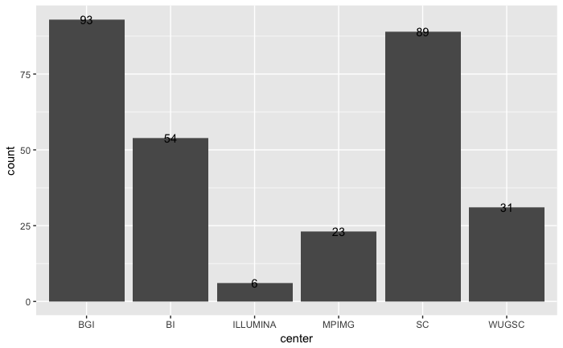

```r
num.samples.by.center <- center.test %>% group_by(center) %>% summarise(count = n()) %>% arrange(count)
ggplot(num.samples.by.center, aes(x = center, y = count, label = count)) + geom_bar(stat = "identity") + geom_text()
```

```r
num.samples.by.center
```

| center | count |
| --- | --- |
| ILLUMINA | 6 |
| MPIMG | 23 |
| WUGSC | 31 |
| BI | 54 |
| SC | 89 |
| BGI | 93 |

##### Number of samples from each population

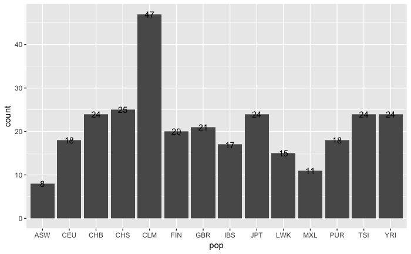

```r
num.samples.by.pop <- center.test %>% group_by(pop) %>% summarise(count = n()) %>% arrange(count)
ggplot(num.samples.by.pop, aes(x = pop, y = count, label = count)) + geom_bar(stat = "identity") + geom_text()
```

```r
num.samples.by.pop
```

| pop | count |
| --- | --- |
| ASW | 8 |
| MXL | 11 |
| LWK | 15 |
| IBS | 17 |
| CEU | 18 |
| PUR | 18 |
| FIN | 20 |
| GBR | 21 |
| CHB | 24 |
| JPT | 24 |

[output cut: 4 more lines]

#### Number of samples from each population by sequencing center

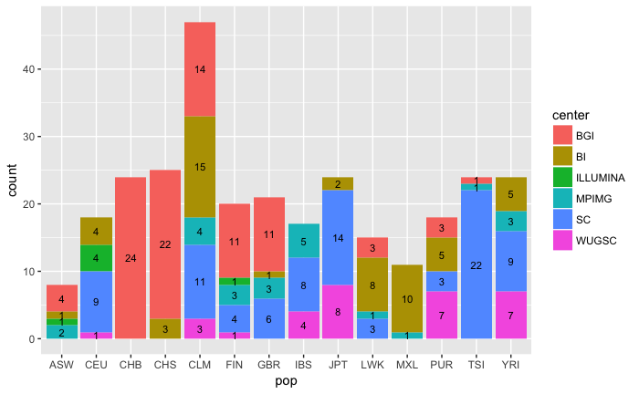

```r
num.samples.by.pop.cent <- center.test %>% group_by(pop, center) %>% summarise(count = n()) %>% arrange(count)
ggplot(num.samples.by.pop.cent, aes(x = pop, y = count, fill = center, label = count)) + geom_bar(stat = "identity") + geom_text(size = 3, position = position_stack(vjust = 0.5))
```

```r
num.samples.by.pop.cent
```

| pop | center | count |
| --- | --- | --- |
| ASW | BI | 1 |
| ASW | ILLUMINA | 1 |
| CEU | WUGSC | 1 |
| FIN | ILLUMINA | 1 |
| FIN | WUGSC | 1 |
| GBR | BI | 1 |
| LWK | MPIMG | 1 |
| MXL | MPIMG | 1 |
| TSI | BGI | 1 |
| TSI | MPIMG | 1 |

[output cut: 38 more lines]

#### Number of samples from each sequencing center by population

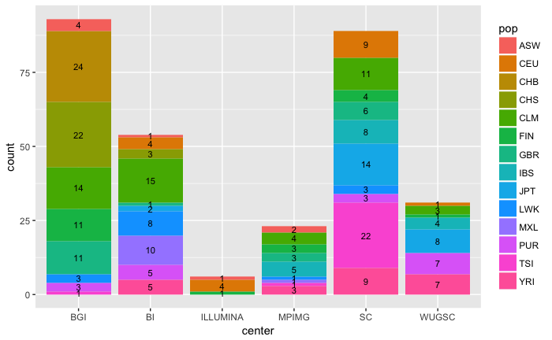

```r
num.samples.by.cent.pop <- center.test %>% group_by(center,pop) %>% summarise(count = n()) %>% arrange(count)
ggplot(num.samples.by.cent.pop, aes(x = center, y = count, fill = pop, label = count)) + geom_bar(stat = "identity") + geom_text(size = 3, position = position_stack(vjust = 0.5))
```

```r
num.samples.by.cent.pop %>% arrange(center, count, pop)
```

| center | pop | count |
| --- | --- | --- |
| BGI | TSI | 1 |
| BGI | LWK | 3 |
| BGI | PUR | 3 |
| BGI | ASW | 4 |
| BGI | FIN | 11 |
| BGI | GBR | 11 |
| BGI | CLM | 14 |
| BGI | CHS | 22 |
| BGI | CHB | 24 |
| BI | ASW | 1 |

[output cut: 38 more lines]

### Generate a model containing only sequencing centers - set center MPIMG as reference

*MPIMG set as reference because of most most linear association between ddPCR and RD for CON1, also, the mean total DUF1220 copy number for this center is intermediate to the others*

```r
reduced.cent <- lm(total.duf ~ BGI + SC + BI + ILLUMINA + WUGSC, center.test)
```

#### Look at normality of the outcome variable

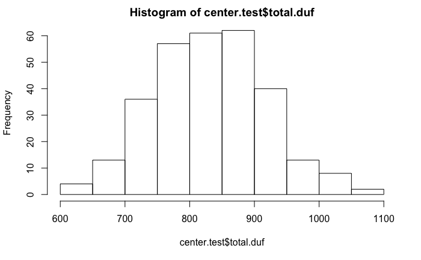

```r
hist(center.test$total.duf)
```

Distribution of outcome looks normal <- Good

#### Look at normality of studentized residuals

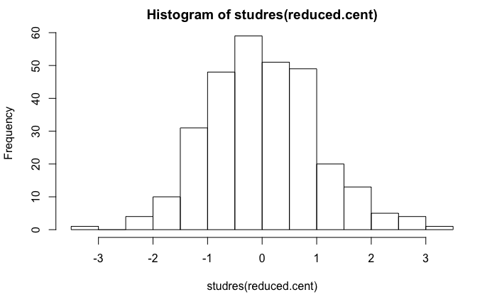

```r
library(MASS)
hist(studres(reduced.cent))
```

```r
detach("package:MASS", unload = T)
```

```
‘MASS’ namespace cannot be unloaded:
  namespace ‘MASS’ is imported by ‘pbkrtest’, ‘car’, ‘lme4’ so cannot be unloaded
```

The residuals of each model appear normally distributed <- Good

#### Look for violations of homoscedascticity and linearity by sequencing center

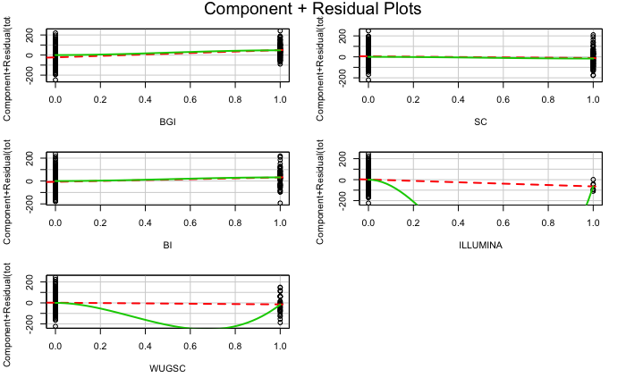

```r
crPlots(reduced.cent)
```

**Illumina group seems to violate homoscedasticity, probably due to small sample size.**

#### Remove ILLUMINA samples from datasets due to violation of homoscedasticity and regenerate model

```r
center.test <- center.test %>% filter(center != "ILLUMINA")
reduced.cent <- lm(total.duf ~ BGI + SC + BI + WUGSC, center.test)
summary(reduced.cent)
```

```
Call:
lm(formula = total.duf ~ BGI + SC + BI + WUGSC, data = center.test)

Residuals:
     Min       1Q   Median       3Q      Max
-224.822  -55.325   -1.146   47.961  243.062

Coefficients:
            Estimate Std. Error t value Pr(>|t|)
(Intercept)   810.38      15.95  50.816  < 2e-16 ***
BGI            72.02      17.81   4.044 6.78e-05 ***
SC            -16.74      17.89  -0.936   0.3502
BI             38.83      19.04   2.039   0.0424 *
WUGSC         -16.05      21.05  -0.763   0.4462
---
Signif. codes:  0 ‘***’ 0.001 ‘**’ 0.01 ‘*’ 0.05 ‘.’ 0.1 ‘ ’ 1

Residual standard error: 76.48 on 285 degrees of freedom
Multiple R-squared:  0.2077,    Adjusted R-squared:  0.1965
F-statistic: 18.67 on 4 and 285 DF,  p-value: 1.203e-13
```

**Conclusions:**  
Differences by sequencing center (not accounting for population) account for ~20% of the variation in Total DUF1220

- Relative to MPIMG, no significant effect of being sequenced at SC or WUGSC
- Effect of being sequenced at BGI (relative to MPIMG) is, on average, an additional 72 copies of DUF1220
- Effect of being sequenced at BI (relative to MPIMG) is, on average, an additional 39 copies of DUF1220

#### Visualize squencing center associations

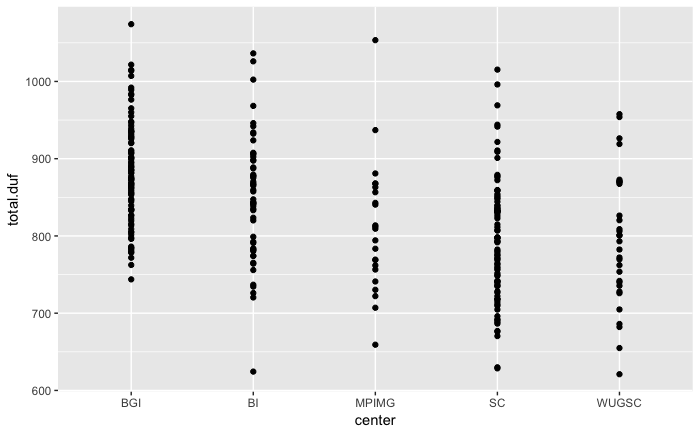

```r
ggplot(center.test, aes(x=center, y = total.duf)) + geom_point()
```

### Calculate model containing only populations - set population LWK as reference

*LWK selected as reference because the mean total DUF1220 copy number for this group is intermediate to the others*

```r
reduced.pop <- lm(total.duf ~ ASW + CEU + CHB + CHS + CLM + FIN + GBR + IBS + JPT + MXL + PUR + TSI + YRI, center.test)
```

#### Look at normality of studentized residuals

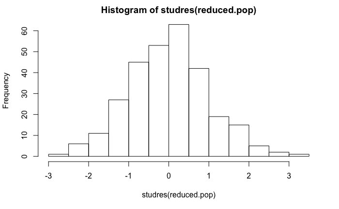

```r
library(MASS)
hist(studres(reduced.pop))
```

```r
detach("package:MASS", unload = T)
```

```
‘MASS’ namespace cannot be unloaded:
  namespace ‘MASS’ is imported by ‘pbkrtest’, ‘car’, ‘lme4’ so cannot be unloaded
```

#### Look for violations of homoscedascticity and linearity by population

*This is currently commented out because it keeps hanging up*

```r
#crPlots(reduced.pop)
```

### Examine results of model with populations only (LWK is reference)

```r
summary(reduced.pop)
```

```
Call:
lm(formula = total.duf ~ ASW + CEU + CHB + CHS + CLM + FIN +
    GBR + IBS + JPT + MXL + PUR + TSI + YRI, data = center.test)

Residuals:
     Min       1Q   Median       3Q      Max
-214.820  -54.839    1.108   45.806  235.336

Coefficients:
            Estimate Std. Error t value Pr(>|t|)
(Intercept)  847.604     20.259  41.837  < 2e-16 ***
ASW           25.860     35.916   0.720  0.47213
CEU          -93.391     29.158  -3.203  0.00152 **
CHB           10.904     25.826   0.422  0.67319
CHS           16.351     25.626   0.638  0.52396
CLM           27.392     23.269   1.177  0.24012
FIN           13.456     27.101   0.497  0.61992
GBR            4.111     26.526   0.155  0.87694
IBS          -29.493     27.796  -1.061  0.28959
JPT          -63.955     25.826  -2.476  0.01387 *
MXL           -8.394     31.147  -0.270  0.78774
PUR          -60.152     27.431  -2.193  0.02916 *
TSI          -63.958     25.826  -2.477  0.01387 *
YRI          -17.251     25.826  -0.668  0.50471
---
Signif. codes:  0 ‘***’ 0.001 ‘**’ 0.01 ‘*’ 0.05 ‘.’ 0.1 ‘ ’ 1

Residual standard error: 78.46 on 276 degrees of freedom
Multiple R-squared:  0.1924,    Adjusted R-squared:  0.1543
F-statistic: 5.057 on 13 and 276 DF,  p-value: 5.005e-08
```

**Conclusions:**

In a model containing populations only (with LWK as reference):  
- Significant effect of being from CEU, JPT, PUR, or TSI (relative to LWK)  
- No other populations have significant effects relative to LWK

#### Visualize population associations

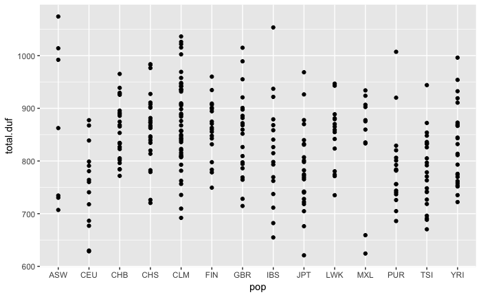

```r
ggplot(center.test, aes(x = pop, y = total.duf)) + geom_point()
```

### Calculate model including all centers and populations (with sequencing center MPIMG and population LWK reference)

```r
full <- lm(total.duf ~ BGI + SC + BI + WUGSC +
           ASW + CEU + CHB + CHS + CLM + FIN + GBR + IBS + JPT + MXL + PUR + TSI + YRI, center.test)
```

#### Look at normality of studentized residuals

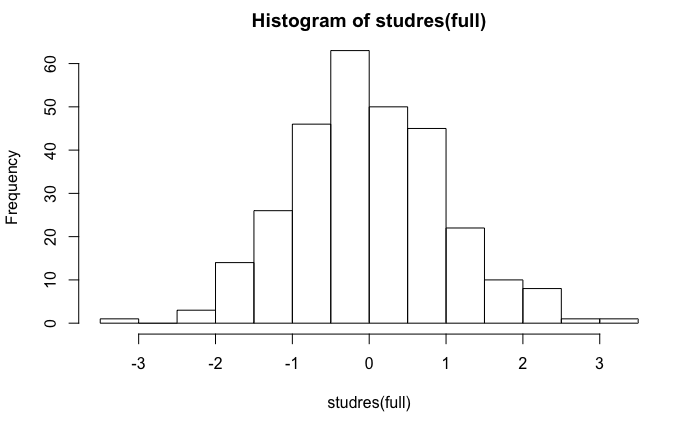

```r
library(MASS)
hist(studres(full))
```

```r
detach("package:MASS", unload = T)
```

```
‘MASS’ namespace cannot be unloaded:
  namespace ‘MASS’ is imported by ‘pbkrtest’, ‘car’, ‘lme4’ so cannot be unloaded
```

### Examine results of full model (with sequencing center MPIMG and population LWK reference)

```r
summary(full)
```

```
Call:
lm(formula = total.duf ~ BGI + SC + BI + WUGSC + ASW + CEU +
    CHB + CHS + CLM + FIN + GBR + IBS + JPT + MXL + PUR + TSI +
    YRI, data = center.test)

Residuals:
     Min       1Q   Median       3Q      Max
-219.586  -48.239   -3.647   48.700  238.936

Coefficients:
            Estimate Std. Error t value Pr(>|t|)
(Intercept)  799.830     25.116  31.845  < 2e-16 ***
BGI           93.803     19.437   4.826 2.33e-06 ***
SC             5.266     18.497   0.285  0.77610
BI            52.426     19.922   2.632  0.00898 **
WUGSC          4.771     21.837   0.218  0.82723
ASW           12.543     34.538   0.363  0.71676
CEU          -64.321     28.049  -2.293  0.02260 *
CHB          -35.124     26.763  -1.312  0.19048
CHS          -24.712     25.857  -0.956  0.34006
CLM           28.957     22.027   1.315  0.18976
FIN            5.564     26.575   0.209  0.83431
GBR           -1.250     25.831  -0.048  0.96143
IBS           14.681     27.620   0.532  0.59549
JPT          -25.212     25.856  -0.975  0.33038
MXL           -8.280     29.695  -0.279  0.78058
PUR          -45.307     26.573  -1.705  0.08933 .
TSI          -24.919     26.092  -0.955  0.34040
YRI           16.235     25.190   0.644  0.51980
---
Signif. codes:  0 ‘***’ 0.001 ‘**’ 0.01 ‘*’ 0.05 ‘.’ 0.1 ‘ ’ 1

Residual standard error: 73.64 on 272 degrees of freedom
Multiple R-squared:  0.2989,    Adjusted R-squared:  0.2551
F-statistic: 6.823 on 17 and 272 DF,  p-value: 1.265e-13
```

#### Visualize relationship between population, sequencing center, and total duf1220

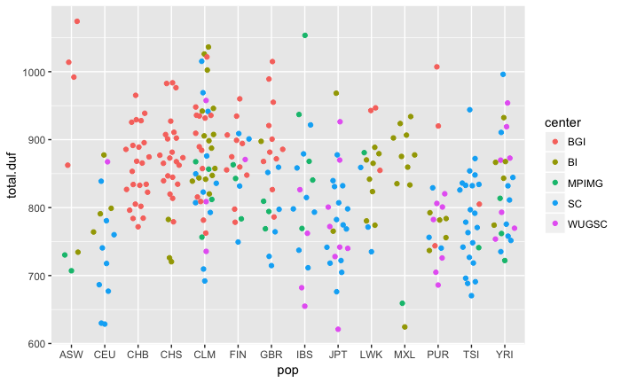

```r
ggplot(center.test,aes(x = pop, y = total.duf, color = center)) + geom_quasirandom()
```

**Conclusions:**

In a model containing both sequencing center and population (with MPIMG and LWK as reference sequencing center and population respectively):  
- Effect of being sequenced at BGI and BI is still significant - Only population that has a significant effect is CEU

## Test which model is best

### Compare a model with no predictors to a model with sequencing centers only

```r
no.pred <- lm(total.duf ~ 1, center.test)
anova(no.pred,reduced.cent)
```

```
Analysis of Variance Table

Model 1: total.duf ~ 1
Model 2: total.duf ~ BGI + SC + BI + WUGSC
  Res.Df     RSS Df Sum of Sq      F    Pr(>F)
1    289 2103992
2    285 1667073  4    436919 18.674 1.203e-13 ***
---
Signif. codes:  0 ‘***’ 0.001 ‘**’ 0.01 ‘*’ 0.05 ‘.’ 0.1 ‘ ’ 1
```

**Conclusion:** Sequencing centers contribute significantly to the prediction of total DUF1220/Sequencing centers have a signficant effect on total DUF1220

### Compare a model with no predictors to a model with populations only

```r
anova(no.pred,reduced.pop)
```

```
Analysis of Variance Table

Model 1: total.duf ~ 1
Model 2: total.duf ~ ASW + CEU + CHB + CHS + CLM + FIN + GBR + IBS + JPT +
    MXL + PUR + TSI + YRI
  Res.Df     RSS Df Sum of Sq     F    Pr(>F)
1    289 2103992
2    276 1699242 13    404750 5.057 5.005e-08 ***
---
Signif. codes:  0 ‘***’ 0.001 ‘**’ 0.01 ‘*’ 0.05 ‘.’ 0.1 ‘ ’ 1
```

**Conclusion:** Population contributes significantly to the prediction of total DUF1220/Population has a signficant effect on total DUF1220

### Compare a model with sequencing centers only to a model containing both sequencing centers and populations

```r
anova(reduced.cent,full)
```

```
Analysis of Variance Table

Model 1: total.duf ~ BGI + SC + BI + WUGSC
Model 2: total.duf ~ BGI + SC + BI + WUGSC + ASW + CEU + CHB + CHS + CLM +
    FIN + GBR + IBS + JPT + MXL + PUR + TSI + YRI
  Res.Df     RSS Df Sum of Sq      F   Pr(>F)
1    285 1667073
2    272 1475026 13    192048 2.7242 0.001223 **
---
Signif. codes:  0 ‘***’ 0.001 ‘**’ 0.01 ‘*’ 0.05 ‘.’ 0.1 ‘ ’ 1
```

**Conclusion:** The two models are significantly different and the full model (sequencing centers and populations) does a better job of predicting total DUF1220 than the model with sequencing center only

### Compare a model with populations only to a model containing both sequencing centers and populations

```r
anova(reduced.pop, full)
```

```
Analysis of Variance Table

Model 1: total.duf ~ ASW + CEU + CHB + CHS + CLM + FIN + GBR + IBS + JPT +
    MXL + PUR + TSI + YRI
Model 2: total.duf ~ BGI + SC + BI + WUGSC + ASW + CEU + CHB + CHS + CLM +
    FIN + GBR + IBS + JPT + MXL + PUR + TSI + YRI
  Res.Df     RSS Df Sum of Sq      F    Pr(>F)
1    276 1699242
2    272 1475026  4    224217 10.337 8.309e-08 ***
---
Signif. codes:  0 ‘***’ 0.001 ‘**’ 0.01 ‘*’ 0.05 ‘.’ 0.1 ‘ ’ 1
```

**Conclusion:**  
The two models are significantly different and the full model (sequencing centers and populations) does a better job of predicting total DUF1220 than the model with populations only

# Overall Conclusions:

- Large and significant effect of being sequenced at BGI or BI - on total DUF1220, remain after correcting for population.
- For analysis of variation in population, consider excluding samples sequenced at those centers, or reporting the data for those centers separately from the data from the other three centers (MPIMG, SC, and WUGSC)
- Consider adding or removing samples from total sample set to equalize number of samples from each population and from each sequencing center

# Look into effects of coverage (total reads) and insert size

#### Effect of insert size

##### Some samples show “zero insert size”, the data is “zero” in the sequence.index file – removing those samples for this analysis since not sure what is going on there

```r
center.test <- center.test %>% filter(mean.insert != 0)
insert.model <- lm(total.duf ~ mean.insert, center.test)
summary(insert.model)
```

```
Call:
lm(formula = total.duf ~ mean.insert, data = center.test)

Residuals:
     Min       1Q   Median       3Q      Max
-226.023  -60.850    0.611   53.780  242.104

Coefficients:
             Estimate Std. Error t value Pr(>|t|)
(Intercept) 721.04186   35.73159  20.179   <2e-16 ***
mean.insert   0.25874    0.08019   3.226   0.0014 **
---
Signif. codes:  0 ‘***’ 0.001 ‘**’ 0.01 ‘*’ 0.05 ‘.’ 0.1 ‘ ’ 1

Residual standard error: 83.34 on 282 degrees of freedom
Multiple R-squared:  0.0356,    Adjusted R-squared:  0.03218
F-statistic: 10.41 on 1 and 282 DF,  p-value: 0.001401
```

**Conclusion:**  
- Insert size has a significant effect of DUF1220

##### Visualize association

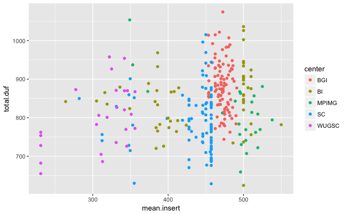

```r
ggplot(center.test, aes(x = mean.insert, y = total.duf, color = center)) + geom_point()
```

#### Investigate a model that includes insert size and sequencing center

```r
center <- lm(total.duf ~ BGI + SC + BI + WUGSC, center.test) # need to regenerate the center model since I removed some datapoints (where mean insert size was 0)
insert.center <- lm(total.duf ~ BGI + SC + BI + WUGSC + mean.insert, center.test)
summary(insert.center)
```

```
Call:
lm(formula = total.duf ~ BGI + SC + BI + WUGSC + mean.insert,
    data = center.test)

Residuals:
     Min       1Q   Median       3Q      Max
-227.846  -55.330   -0.656   46.473  250.304

Coefficients:
            Estimate Std. Error t value Pr(>|t|)
(Intercept) 784.7856    54.3176  14.448  < 2e-16 ***
BGI          72.7907    17.8101   4.087 5.72e-05 ***
SC          -13.9456    18.7002  -0.746   0.4565
BI           41.1516    19.5461   2.105   0.0362 *
WUGSC        -0.7562    28.9748  -0.026   0.9792
mean.insert   0.0526     0.1067   0.493   0.6225
---
Signif. codes:  0 ‘***’ 0.001 ‘**’ 0.01 ‘*’ 0.05 ‘.’ 0.1 ‘ ’ 1

Residual standard error: 76.18 on 278 degrees of freedom
Multiple R-squared:  0.2056,    Adjusted R-squared:  0.1913
F-statistic: 14.39 on 5 and 278 DF,  p-value: 1.56e-12
```

##### Compare model of sequencing centers only to model with sequencing center and insert size

```r
anova(center, insert.center)
```

```
Analysis of Variance Table

Model 1: total.duf ~ BGI + SC + BI + WUGSC
Model 2: total.duf ~ BGI + SC + BI + WUGSC + mean.insert
  Res.Df     RSS Df Sum of Sq      F Pr(>F)
1    279 1614820
2    278 1613410  1    1409.6 0.2429 0.6225
```

**Conclusion:**  
- A model with both sequencing centers and mean insert size is not better than a model with sequencing centers allone

```r
tot.reads.model <- lm(total.duf ~ tot.reads, center.test)
summary(tot.reads.model)
```

```
Call:
lm(formula = total.duf ~ tot.reads, data = center.test)

Residuals:
     Min       1Q   Median       3Q      Max
-207.347  -60.282    0.653   51.055  241.407

Coefficients:
             Estimate Std. Error t value Pr(>|t|)
(Intercept) 8.129e+02  1.441e+01  56.400   <2e-16 ***
tot.reads   9.797e-08  5.976e-08   1.639    0.102
---
Signif. codes:  0 ‘***’ 0.001 ‘**’ 0.01 ‘*’ 0.05 ‘.’ 0.1 ‘ ’ 1

Residual standard error: 84.57 on 281 degrees of freedom
  (1 observation deleted due to missingness)
Multiple R-squared:  0.009473,  Adjusted R-squared:  0.005948
F-statistic: 2.687 on 1 and 281 DF,  p-value: 0.1023
```

**Conclusion:**  
- Number of total reads is not linearly associated with Total DUF1220

##### Visualize association

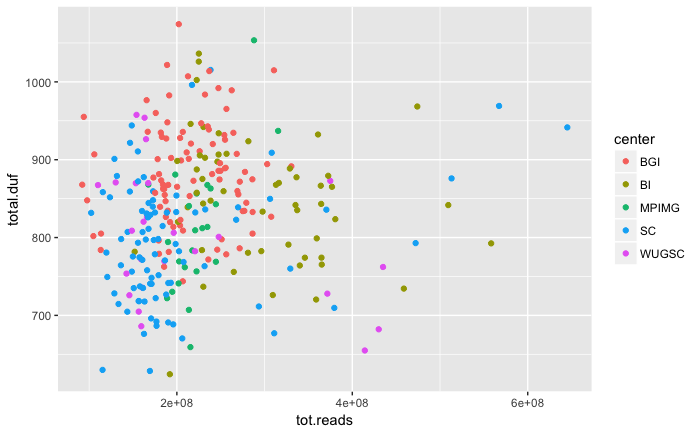

```r
ggplot(center.test, aes(x = tot.reads, y = total.duf, color = center)) + geom_point()
```